# RepData_PeerAssessment1

Paolo Flaim

12 luglio 2018

## Loading and preprocessing the data

1. Load the data (i.e. read.csv())
2. Process/transform the data (if necessary) into a format suitable for your analysis

```r
#Load the data
file <- unzip("activity.zip", overwrite = TRUE)
rawdata <- read.csv(file, header=TRUE, sep=",", colClasses = c("integer", "Date", "integer"), stringsAsFactors = FALSE)

#Process/transform the data
activities <- na.omit(rawdata)
```

## What is mean total number of steps taken per day?

1. Make a histogram of the total number of steps taken each day
2. Calculate and report the mean and median total number of steps taken per day

```r
library(dplyr)
```

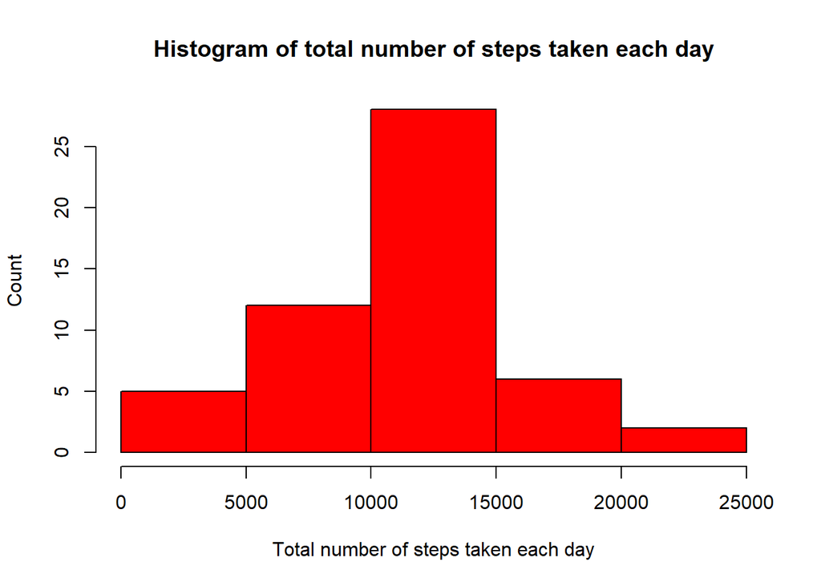

```r
#group steps by days and sum
stepsperday <- activities %>% group_by(date) %>% summarise(Totalsteps = sum(steps))
#histogram of the total number of steps taken each day
hist(stepsperday$Totalsteps,
     xlab="Total number of steps taken each day",
     ylab="Count",
     main="Histogram of total number of steps taken each day",
     col=2)
```

```r
#the mean and median total number of steps taken per day
meanstepsperday <- mean(stepsperday$Totalsteps)
medianstepsperday <- median(stepsperday$Totalsteps)
```

The mean step per day are 10766.1886792453 and the median 10765.

## What is the average daily activity pattern?

1. Make a time series plot (i.e. type = “l”) of the 5-minute interval (x-axis) and the average number of steps taken, averaged across all days (y-axis)
2. Which 5-minute interval, on average across all the days in the dataset, contains the maximum number of steps?

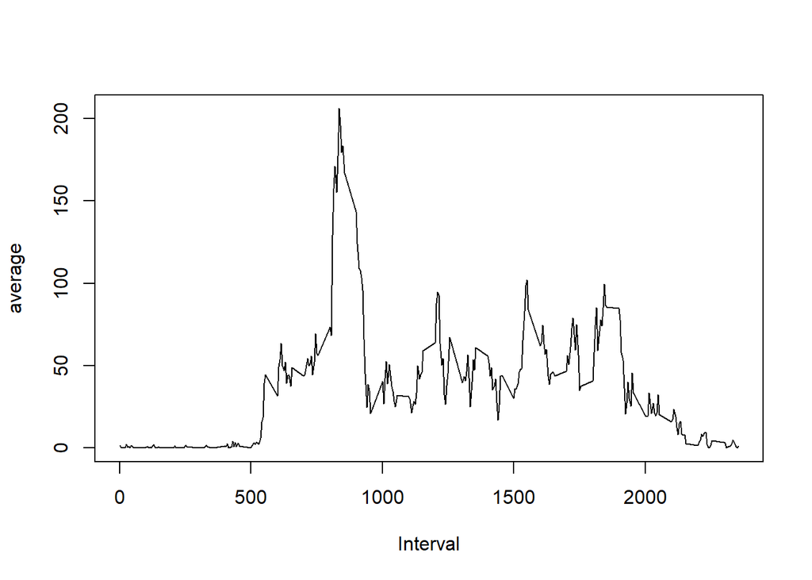

```r
#Make a time series plot (i.e. type = "l") of the 5-minute interval (x-axis)
#and the average number of steps taken, averaged across all days (y-axis)
averageSteps <- activities %>% group_by(interval) %>% summarise(avg = mean(steps))
plot(averageSteps$interval, averageSteps$avg, type= "l", xlab="Interval", ylab="average")
```

```r
#Which 5-minute interval, on average across all the days in the dataset,
#contains the maximum number of steps?
maxaveragesteps <- averageSteps[averageSteps$avg == max(averageSteps$avg),]
```

The maximum average steps are contained in the interval 835.